# Week 6 Homework: Comparisons

Author

Affiliation

Yasmeen R’ghioui

George Washington University

Published

February 26, 2026

## Week 6 — Comparisons

## 1) Environment Setup

**Description**: This dataset was sourced from the Kaggle website and was created by Nidula Elgiriyewithana. It was last updated 11 hours ago. It is updated daily. This dataset provides daily weather information for capital cities around the world. Unlike forecast data, this dataset offers a comprehensive set of features that reflect the current weather conditions around the world. Starting from August 29, 2023. It provides over 40+ features , including temperature, wind, pressure, precipitation, humidity, visibility, air quality measurements and more. The dataset is valuable for analyzing Global weather patterns, exploring climate trends, and understanding the relationships between different weather parameters.

```python
import numpy as np
import pandas as pd
import matplotlib.pyplot as plt
import seaborn as sns
import plotly.express as px
from sklearn.datasets import load_iris
import calendar
data = pd.read_csv("Global_Weather_Repository.csv")
```

```python
morocco_data = data[data["country"] == "Morocco"]
trinidad_data = data[data["country"] == "Trinidad and Tobago"]
```

## 2) Dot Plots

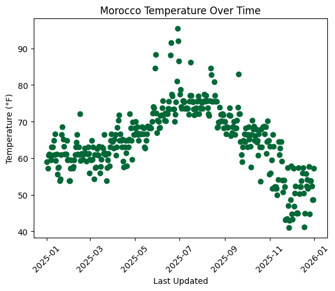

```python
morocco_data["last_updated"] = pd.to_datetime(morocco_data["last_updated"])
morocco_2025 = morocco_data[morocco_data["last_updated"].dt.year == 2025]

plt.figure()
plt.scatter(morocco_2025["last_updated"], morocco_2025["temperature_fahrenheit"], color = "#006837")
plt.xticks(rotation=45)
plt.xlabel("Last Updated")
plt.ylabel("Temperature (°F)")
plt.title("Morocco Temperature Over Time")
plt.show()
```

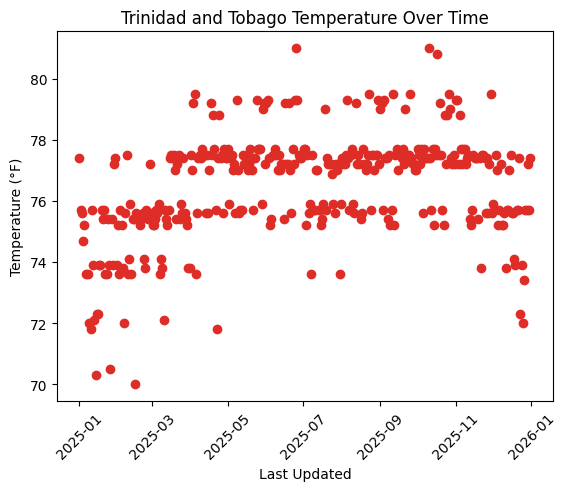

```python
trinidad_data["last_updated"] = pd.to_datetime(trinidad_data["last_updated"])
trinidad_2025 = trinidad_data[trinidad_data["last_updated"].dt.year == 2025]

plt.figure()
plt.scatter(trinidad_2025["last_updated"], trinidad_2025["temperature_fahrenheit"], color = "#de2d26")
plt.xticks(rotation=45)
plt.xlabel("Last Updated")
plt.ylabel("Temperature (°F)")
plt.title("Trinidad and Tobago Temperature Over Time")
plt.show()
```

- We can observe that temperatures tend to stay centered around 76-78. There isn’t much of a trend in temperature as the months progress. This is because Trinidad and Tobago is near the equator and doesn’t have seasons.

## 3) Slope Graphs

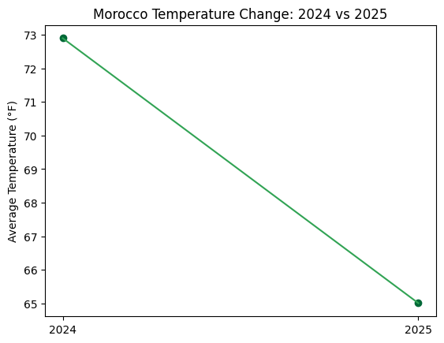

```python
morocco_data["year"] = morocco_data["last_updated"].dt.year

morocco_2425 = morocco_data[morocco_data["year"].isin([2024, 2025])]

yearly_avg = (
    morocco_2425
    .groupby("year")["temperature_fahrenheit"]
    .mean()
    .reset_index()
)

plt.figure()

x = [0, 1]
y = yearly_avg["temperature_fahrenheit"].values

plt.plot(x, y, color = "#31a354")
plt.scatter(x, y, color = "#006837")
plt.xticks([0, 1], yearly_avg["year"])
plt.ylabel("Average Temperature (°F)")
plt.title("Morocco Temperature Change: 2024 vs 2025")

plt.show()
```

- There is a clear decline in the average temperature from 2024 to 2025. Morocco saw unbelievable highs in 2024 compared to any other year, so it makes sense.

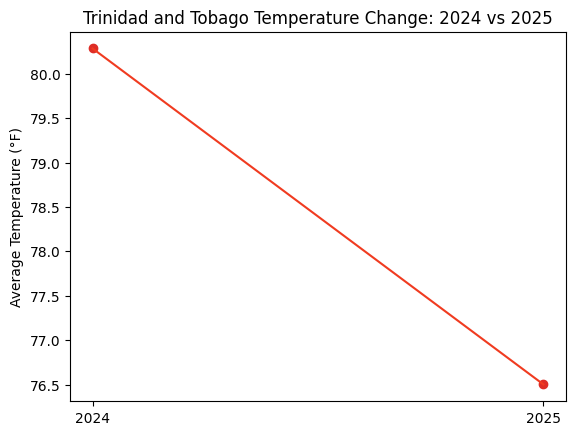

```python
trinidad_data["year"] = trinidad_data["last_updated"].dt.year

trinidad_2425 = trinidad_data[trinidad_data["year"].isin([2024, 2025])]

yearly_avg = (
    trinidad_2425
    .groupby("year")["temperature_fahrenheit"]
    .mean()
    .reset_index()
)

plt.figure()

x = [0, 1]
y = yearly_avg["temperature_fahrenheit"].values

plt.plot(x, y, color = "#f03b20")
plt.scatter(x, y, color = "#de2d26")
plt.xticks([0, 1], yearly_avg["year"])
plt.ylabel("Average Temperature (°F)")
plt.title("Trinidad and Tobago Temperature Change: 2024 vs 2025")

plt.show()
```

- There is a clear decline in the average temperature from 2024 to 2025. Trinidad also saw highs in 2024 like no other year, so again, it makes sense.

## 4) Small-Multiples Charts

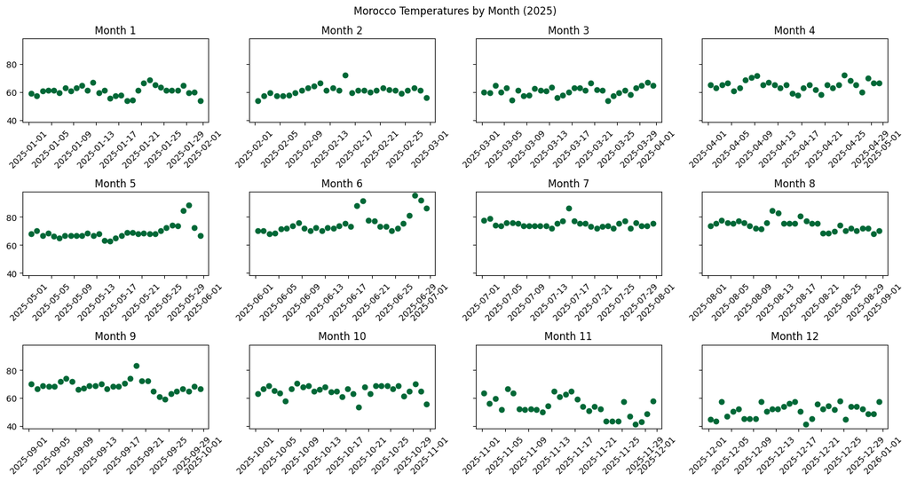

```python
morocco_data["last_updated"] = pd.to_datetime(morocco_data["last_updated"])

morocco_data = morocco_data[morocco_data["country"] == "Morocco"]

morocco_2025 = morocco_data[
    morocco_data["last_updated"].dt.year == 2025
].copy()

morocco_2025["month"] = morocco_2025["last_updated"].dt.month

fig, axes = plt.subplots(3, 4, figsize=(15, 8), sharey=True)

for i, month in enumerate(range(1, 13)):
    ax = axes[i // 4, i % 4]

    month_data = morocco_2025[morocco_2025["month"] == month]

    ax.scatter(
        month_data["last_updated"],
        month_data["temperature_fahrenheit"],
        color = "#006837"
    )

    ax.set_title(f"Month {month}")
    ax.tick_params(axis='x', rotation=45)

plt.suptitle("Morocco Temperatures by Month (2025)")
plt.tight_layout()
plt.show()
```

- This is the trend of Morocco’s temperatures by month. We can see as the seasons progress, the temperatures correlate to their respective seasons.

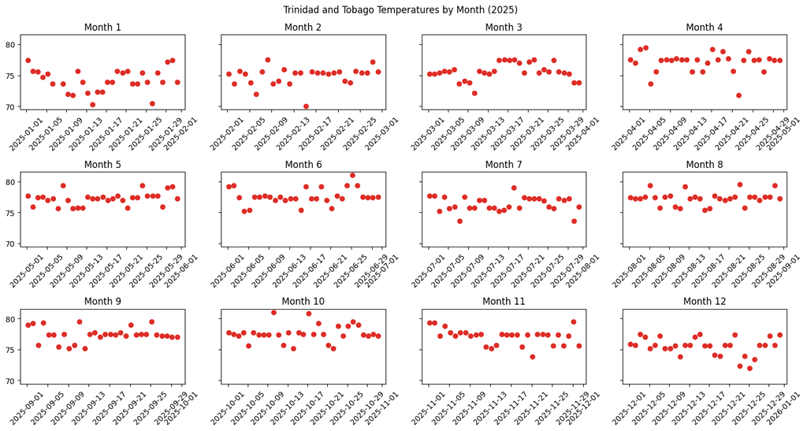

```python
trinidad_data["last_updated"] = pd.to_datetime(trinidad_data["last_updated"])

trinidad_data = trinidad_data[trinidad_data["country"] == "Trinidad and Tobago"]

trinidad_2025 = trinidad_data[
    trinidad_data["last_updated"].dt.year == 2025
].copy()

trinidad_2025["month"] = trinidad_2025["last_updated"].dt.month

fig, axes = plt.subplots(3, 4, figsize=(15, 8), sharey=True)

for i, month in enumerate(range(1, 13)):
    ax = axes[i // 4, i % 4]

    month_data = trinidad_2025[trinidad_2025["month"] == month]

    ax.scatter(
        month_data["last_updated"],
        month_data["temperature_fahrenheit"],
        color = "#de2d26"
    )

    ax.set_title(f"Month {month}")
    ax.tick_params(axis='x', rotation=45)

plt.suptitle("Trinidad and Tobago Temperatures by Month (2025)")
plt.tight_layout()
plt.show()
```

- This is the trend of Trinidad’s average temperatures by month. The temperatures mostly stay the same throughout the month and year since Trinidad doesn’t really experience seasons. We can observe that it does get colder than usual in January and Febuary though it only drops to about 70.

## 5) Normalized View - Bar Charts

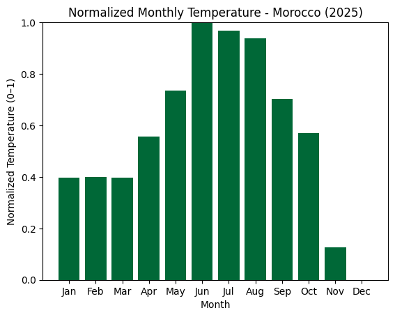

```python
morocco_2025 = morocco_data[
    morocco_data["last_updated"].dt.year == 2025
].copy()

morocco_2025["month"] = morocco_2025["last_updated"].dt.month

monthly_avg = (
    morocco_2025
    .groupby("month")["temperature_fahrenheit"]
    .mean()
    .reset_index()
)

min_temp = monthly_avg["temperature_fahrenheit"].min()
max_temp = monthly_avg["temperature_fahrenheit"].max()

monthly_avg["temp_normalized"] = (
    (monthly_avg["temperature_fahrenheit"] - min_temp)
    / (max_temp - min_temp)
)

monthly_avg["month_name"] = monthly_avg["month"].apply(lambda x: calendar.month_abbr[x])

plt.figure()
plt.bar(
    monthly_avg["month_name"],
    monthly_avg["temp_normalized"],
    color="#006837"
)
plt.xlabel("Month")
plt.ylabel("Normalized Temperature (0–1)")
plt.title("Normalized Monthly Temperature - Morocco (2025)")

plt.ylim(0, 1)
plt.show()
```

- We can observe that Morocco records higher temperatures in the summer and colder temperatures in the winter.

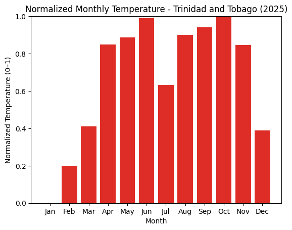

```python
trinidad_2025 = trinidad_data[
    trinidad_data["last_updated"].dt.year == 2025
].copy()

trinidad_2025["month"] = trinidad_2025["last_updated"].dt.month

monthly_avg = (
    trinidad_2025
    .groupby("month")["temperature_fahrenheit"]
    .mean()
    .reset_index()
)

min_temp = monthly_avg["temperature_fahrenheit"].min()
max_temp = monthly_avg["temperature_fahrenheit"].max()

monthly_avg["temp_normalized"] = (
    (monthly_avg["temperature_fahrenheit"] - min_temp)
    / (max_temp - min_temp)
)

monthly_avg["month_name"] = monthly_avg["month"].apply(lambda x: calendar.month_abbr[x])

plt.figure()
plt.bar(
    monthly_avg["month_name"],
    monthly_avg["temp_normalized"],
    color="#de2d26"
)
plt.xlabel("Month")
plt.ylabel("Normalized Temperature (0–1)")
plt.title("Normalized Monthly Temperature - Trinidad and Tobago (2025)")

plt.ylim(0, 1)
plt.show()
```

- We can observe that Trinidad records around the same high temperatures throughout the year. They do drop in the winter a little, but for the most part, they remain consistent and high.